# Item Thresholds

Psychologische Institut für psychologische Methodenlehre, Evaluation und Statistik

~

Carolina Fellinghauer

carolina.fellinghauer@uzh.ch

14 10 2020

# Getting ready

Load following packages.

```r
# install and load following R-packages
library(eRm)
library(iarm)
```

and load the Stress Related Growth data (SRG) :

```r
# get the SRG dataset from GitHub

urlfile <- "https://raw.githubusercontent.com/CarolinaFellinghauer/UNIZH_HS2020_Rasch/master/Data/SRG_Data_Course_UNIZH.csv?token=AB5GB47UIUWV7F5NMGA33T27K5IQ2"

srg.data <- read.csv(url(urlfile))

dim(srg.data)
```

```
[1] 450  26
```

```r
colnames(srg.data)
```

```
 [1] "X"                      "ID"                     "Age"
 [4] "Gender"                 "Completeness"           "para.tetra_1"
 [7] "traumatic_nontraumatic" "PersStat"               "SRG1"
[10] "SRG2"                   "SRG3"                   "SRG4"
[13] "SRG5"                   "SRG6"                   "SRG7"
[16] "SRG8"                   "SRG9"                   "SRG10"
[19] "SRG11"                  "SRG12"                  "SRG13"
[22] "SRG14"                  "SRG15"                  "TP"
[25] "ID_Unik"                "wgt"
```

```r
srg.items <- c("SRG1", "SRG2", "SRG3", "SRG4", "SRG5", "SRG6", "SRG7", "SRG8", "SRG9",
    "SRG10", "SRG11", "SRG12", "SRG13", "SRG14", "SRG15")


# dataset with only the SRG items
data.srg <- srg.data[, srg.items]

# check response coding (frequencies including missing values) for each SRG-item
apply(data.srg, 2, table, useNA = "always")
```

```
     SRG1 SRG2 SRG3 SRG4 SRG5 SRG6 SRG7 SRG8 SRG9 SRG10 SRG11 SRG12 SRG13 SRG14
0     163  256  128  142  117  161  161  205  139    88   138   259    64   144
1     221  139  201  177  155  171  174  164  211   237   203   143   206   174
2      62   51  120  129  178  116  115   81  100   124   109    47   180   131
<NA>    4    4    1    2    0    2    0    0    0     1     0     1     0     1
     SRG15
0       63
1      159
2      228
<NA>     0
```

# Rasch Thresholds

When fitting data with polytomous response options using the PCM, the difficulty thresholds have to be investigated more closely. In Rasch analysis, thresholds are the equal probability points which separate two adjacent difficulty levels. More concretely, for an item with 3 response options 2 thresholds are computed. These 2 thresholds would correspond to the points on the measurement continuum where a respondent switches from scoring 0 to scoring 1 (first threshold) and from 1 to 2 (second threshold) (Mair 2018).

The partial credit model (PCM) parameterisation allows distances between adjacent thresholds to vary. However, in some circumstances, such as many response options, vaguely defined response options, etc… reversing or complete disordering of thresholds can happen, i.e. the intended ordering of thresholds is not working and some thresholds are reversed.

# Diagnostics

In presence of disordered thresholds, recoding of response options can be a solution to improve the fit of the items and the quality of the scale in general. Disordered thresholds can be detected through different means, also depending what R-package is used:

- numeric output analysis
- visual analysis:  
  – threshold map (`R2R` - *not on CRAN yet*)  
  – person-item map (`eRm`)  
  – ICC curves (`eRm`)

## Numeric Output Analysis

As, shown earlier in the course, the SRG data is polytomous and can be calibrated with the partial credit model, `PCM()`. To obtain the thresholds, the function `thresholds()` is run over the PCM output.

```r
PCM.srg <- PCM(data.srg)
Thres.srg <- thresholds(PCM.srg)
Thres.srg
```

```
Design Matrix Block 1:
      Location Threshold 1 Threshold 2
SRG1   0.85724    -0.47843     2.19290
SRG2   1.43162     0.74117     2.12207
SRG3   0.17207    -0.85636     1.20051
SRG4   0.20602    -0.58855     1.00059
SRG5  -0.22603    -0.83563     0.38358
SRG6   0.39365    -0.33831     1.12560
SRG7   0.40817    -0.34876     1.16510
SRG8   0.88624     0.15063     1.62184
SRG9   0.37835    -0.74505     1.50174
SRG10 -0.15864    -1.56990     1.25262
SRG11  0.30914    -0.73240     1.35068
SRG12  1.48944     0.73049     2.24839
SRG13 -0.72935    -2.00721     0.54851
SRG14  0.20653    -0.55193     0.96498
SRG15 -0.97265    -1.87336    -0.07193
```

The `threshold` output shows a column for the location of an item on the measurement continuum. The location of an item is simply the average difficulty of an item and represents the average of the difficulty thresholds of an item.

For example the location of item 1 is the mean of`-0.47843` and `2.19290`.

```r
(-0.47843 + 2.1929)/2
```

```
[1] 0.857235
```

```r
# or

mean(c(-0.47843, 2.1929))
```

```
[1] 0.857235
```

```r
# corresponds to the location in table : 0.85724
```

Run `names(Thres.srg)` to understand how to obtain the output. The data matrix is obtained as follows:

```r
names(Thres.srg)
```

```
[1] "threshpar"   "se.thresh"   "threshtable"
```

```r
Thres.srg$threshtable
```

```
$`1`
        Location Threshold 1 Threshold 2
SRG1   0.8572373  -0.4784296  2.19290415
SRG2   1.4316191   0.7411704  2.12206769
SRG3   0.1720746  -0.8563564  1.20050554
SRG4   0.2060229  -0.5885481  1.00059400
SRG5  -0.2260281  -0.8356332  0.38357704
SRG6   0.3936472  -0.3383062  1.12560053
SRG7   0.4081678  -0.3487618  1.16509728
SRG8   0.8862379   0.1506336  1.62184217
SRG9   0.3783455  -0.7450451  1.50173610
SRG10 -0.1586393  -1.5699011  1.25262246
SRG11  0.3091380  -0.7324037  1.35067972
SRG12  1.4894372   0.7304875  2.24838678
SRG13 -0.7293461  -2.0072058  0.54851358
SRG14  0.2065266  -0.5519254  0.96497862
SRG15 -0.9726469  -1.8733623 -0.07193157
```

```r
# to have a matrix format type:
Thres.srg$threshtable$`1`
```

```
        Location Threshold 1 Threshold 2
SRG1   0.8572373  -0.4784296  2.19290415
SRG2   1.4316191   0.7411704  2.12206769
SRG3   0.1720746  -0.8563564  1.20050554
SRG4   0.2060229  -0.5885481  1.00059400
SRG5  -0.2260281  -0.8356332  0.38357704
SRG6   0.3936472  -0.3383062  1.12560053
SRG7   0.4081678  -0.3487618  1.16509728
SRG8   0.8862379   0.1506336  1.62184217
SRG9   0.3783455  -0.7450451  1.50173610
SRG10 -0.1586393  -1.5699011  1.25262246
SRG11  0.3091380  -0.7324037  1.35067972
SRG12  1.4894372   0.7304875  2.24838678
SRG13 -0.7293461  -2.0072058  0.54851358
SRG14  0.2065266  -0.5519254  0.96497862
SRG15 -0.9726469  -1.8733623 -0.07193157
```

```r
# to remove the locations type:
Thres.srg$threshtable$`1`[, -1]
```

```
      Threshold 1 Threshold 2
SRG1   -0.4784296  2.19290415
SRG2    0.7411704  2.12206769
SRG3   -0.8563564  1.20050554
SRG4   -0.5885481  1.00059400
SRG5   -0.8356332  0.38357704
SRG6   -0.3383062  1.12560053
SRG7   -0.3487618  1.16509728
SRG8    0.1506336  1.62184217
SRG9   -0.7450451  1.50173610
SRG10  -1.5699011  1.25262246
SRG11  -0.7324037  1.35067972
SRG12   0.7304875  2.24838678
SRG13  -2.0072058  0.54851358
SRG14  -0.5519254  0.96497862
SRG15  -1.8733623 -0.07193157
```

To check if the thresholds for each item are strictly ordered, we can use the function `order` in an `apply()` call. Apply, as its name implies, applies a function (FUN) on a data matrix (X) either by row `apply(X, 1, FUN)` or by column `apply(X, 2, FUN)`. Check `?apply` for more informations. The function `order`gives an index for the position or rank of a number in a vector, 1 standing for the smallest or biggest number of a numeric vector, if `decreasing =` is set to FALSE or TRUE.

```r
apply(Thres.srg$threshtable$`1`[, -1], 1, order, decreasing = FALSE)
```

```
     SRG1 SRG2 SRG3 SRG4 SRG5 SRG6 SRG7 SRG8 SRG9 SRG10 SRG11 SRG12 SRG13 SRG14
[1,]    1    1    1    1    1    1    1    1    1     1     1     1     1     1
[2,]    2    2    2    2    2    2    2    2    2     2     2     2     2     2
     SRG15
[1,]     1
[2,]     2
```

## Visual Analysis

### Threshold Map

As, with increasing number of thresholds, the detection of disordered thresholds may be difficult just basing on the logit-scaled threshold values, a visual analysis may be more efficient. An easy way to investigate threshold ordering is to look at a threshold map. The difficulty thresholds of the items can be visualized with the `ThresholdMap()` function.

```r
thres_map_fct <- "https://raw.githubusercontent.com/CarolinaFellinghauer/UNIZH_HS2020_Rasch/master/RFunctions/threshold_map_fct.r"

source(url(thres_map_fct))
```

A threshold map shows the item difficulty position of a scale given an observed range of person abilities. It runs on the the threshold output of a Rasch analysis from the package `eRm`.

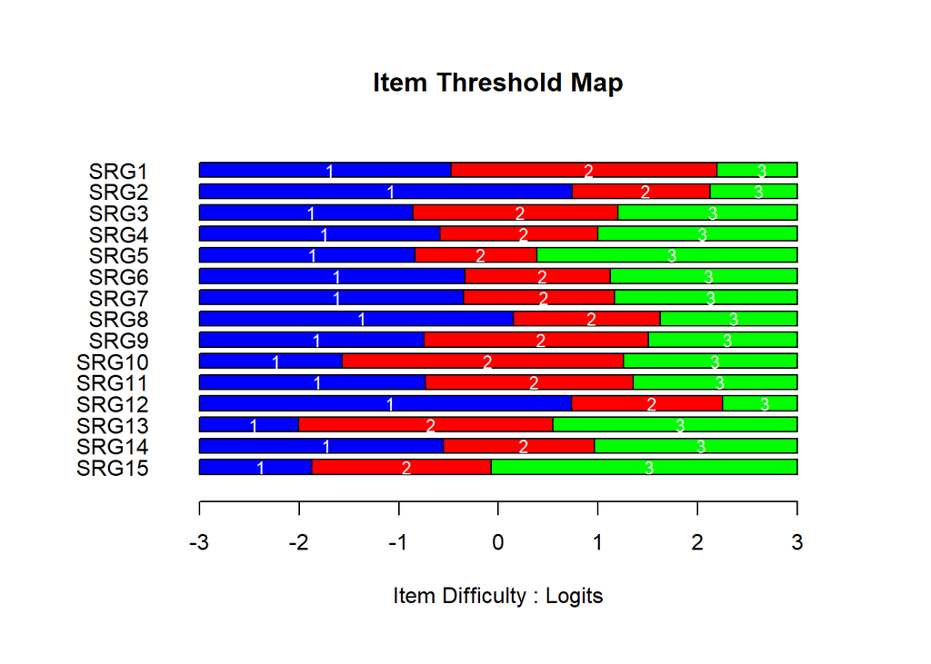

```r
ThresholdMap(Thres.srg)
```

This map is very useful to see immediately if a scale’s difficulty thresholds are working or not. The SRG is an example of a well working scale. In presence of disordered thresholds, the colourful band would be replaced by a warning.

### Person-Item Map

Visual inspection of the thresholds can also be done with several functions from the `eRm`package. The person-item map `plotPImap()` is a more complete plot which shows together, on one figure, the difficulty thresholds of each item and the person ability distribution. Options like the plot title (`main=`) and the item axis sorting (`sorted=TRUE`) can be changed to improve the layout of the figure.

The threshold diagnostics are obtained with the information in the right margin of the plot, where an asterisk (*) indicates if an item has disordered thresholds.

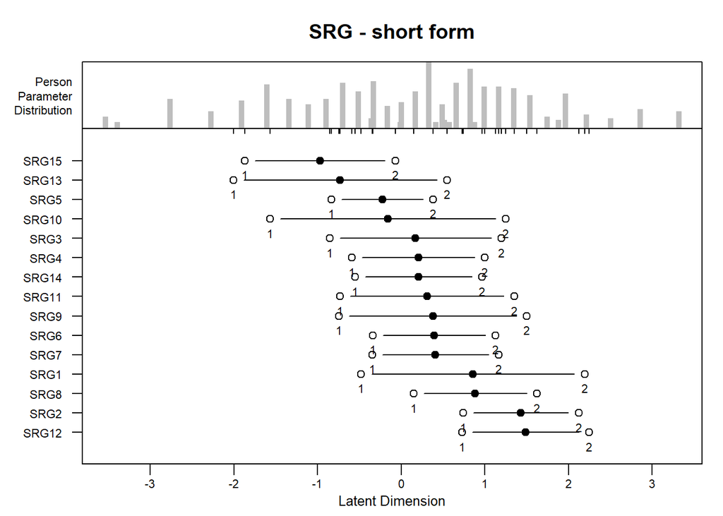

```r
plotPImap(PCM.srg, sorted = TRUE, main = "SRG - short form")
```

Here also, as before, only perfectly ordered thresholds.

This plot adds perspectives to the threshold map and is not only useful for threshold diagnostics. The person-item map would show ‘how’ the thresholds are ordered. It also shows if the measurement continuum of the instrument and the ability levels of the respondents in the sample. The distribution of the person abilities are shown in the upper part of the figure.

The scope of the scale, i.e. the range that the instrument measures, can be seen. The SRG range, roughly, from -2 to 2, is a little bit narrow. In general, the larger the better, a range from at least -4 to 4 would be more ideal.

The item difficulty hierarchy can be seen. The easiest and most difficult items can be detected immediately.

Remember that the probability to endorse a response ($X = 1$) under the dichotomous Rasch model is:

$$P(X=1|\theta_j) = \frac{exp(\theta_j - \beta_i)}{1 + exp(\theta_j - \beta_i)}$$

where $\theta$ stands for the ability of the person $j$ and $\beta$ for the difficulty of the item $i$.

For example, when the difficulty of an item equals the ability of the person ($\theta_j = \beta_i$) the probability of responding 1 is:

```r
theta <- 0.85724
beta <- 0.85724

exp(theta - beta)/(1 + exp(theta - beta))
```

```
[1] 0.5
```

```r
# the probability of endorsing the item 0.5
```

when the difficulty of the item is higher than ability of the person ($\theta_j < \beta_i$), the probability of responding 1 becomes:

```r
# for e.g. using the previous beta of item SRG1

theta <- 0.25
beta <- 0.85724

exp(theta - beta)/(1 + exp(theta - beta))
```

```
[1] 0.352689
```

```r
# the probability of endorsing the item is small
```

when the ability of the person is higher than the difficulty of the item ($\theta_j > \beta_i$), the probability of responding 1 becomes:

```r
theta <- 2
beta <- 0.85724

exp(theta - beta)/(1 + exp(theta - beta))
```

```
[1] 0.758186
```

```r
# the probability of endorsing the item gets big
```

Here, for example SRG 15 *I learned that there are more people who care about me than I thought* is the ‘easiest’ item (see the person-item map). Most persons endorsed it and responded with $X=1$. Concretely, it seems that after a stressful event, most persons had grown in their perception on how much others care for them.

At the other end of the continuum we find SRG 12 *I learned that I want to have some impact on the world* as being the least likely to be endorsed.

### ICC curves

the `plotICC()` in `eRm` function allows a more in depth analysis of the threshold disordering and where it occurs using the item-category characteristic curve.

Example of the item-category characteristic curve for SRG item 5 *I learned to work through models and not just give up.*

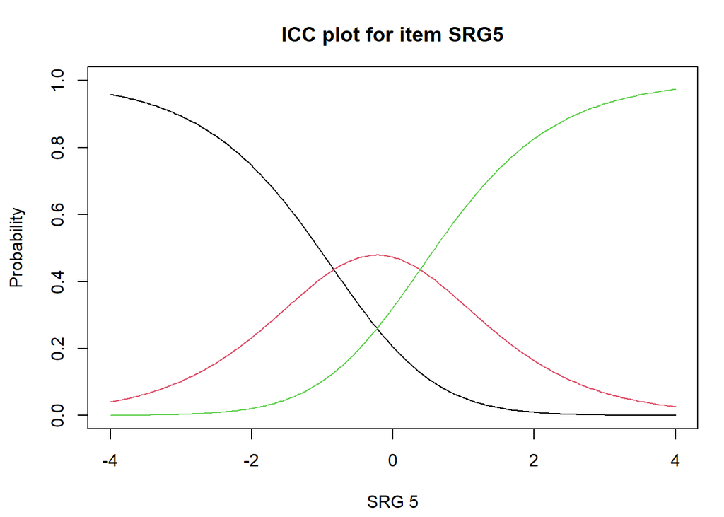

```r
plotICC(PCM.srg, item.subset=5,  xlab = "SRG 5", ylab = "Probability",
        legpos = FALSE, #no legend here
        ask = FALSE)  #for several plot, R interactive can make sense
```

The ICC plot shows on the y-axis the probability of responding 0 (black line), 1 (red line), or 2 (green line) given a latent ability ($\theta$), the x-axis. For example, for a person of ability $\theta = 0$ the most likely response would be 1.

The item SRG 5 had a location of `-0.22603`, a first threshold of `-0.83563` and a second threshold of `0.38358`.

Drawing a vertical line from the x-axis point `-0.83563` falls on the intersection of the black and the red line, where response 0 and 1 have the same probability. Meaning, that for a person with ability `-0.83563` it is not sure if 0 or 1 will be responded.

Drawing a vertical line from the x-axis point `0.38358` falls on the intersection of the red and the green line, where response 1 and 2 have the same probability. Meaning, that for a person with ability `0.38358` it is not sure if 1 or 2 will be responded.

# Adjustment

## Item Collapsing

In presence of disordered thresholds recoding of response options is the solution. For example, if an item with three response options, 0, 1, 2 shows an output with a threshold ordering of 0, 2, 1, the responses 2 and 1 are reversed and are better aggregated resulting in a dichotomous item coded as 0 and 1 (or 0,1,1)

```r
# example of collapsing code let's imagine SRG-8 would have had disordered
# thresholds...

# if the analysis of thresholds would have shown that options 2 and 1 are
# reversed response options 2 and 1 could be collapsed

data.srg[which(data.srg[, "SRG8"] == 2), "SRG8"] <- 1

# frequency tables per column should show that SRG8 has now only 2 responses left
apply(data.srg, 2, table, useNA = "always")
```

```
$SRG1

   0    1    2 <NA>
 163  221   62    4

$SRG2

   0    1    2 <NA>
 256  139   51    4

$SRG3

   0    1    2 <NA>
 128  201  120    1

$SRG4

   0    1    2 <NA>
 142  177  129    2

$SRG5

   0    1    2 <NA>
 117  155  178    0

$SRG6

   0    1    2 <NA>
 161  171  116    2

$SRG7

   0    1    2 <NA>
 161  174  115    0

$SRG8

   0    1 <NA>
 205  245    0

```

[output cut: 19 more lines]

```

$SRG13

   0    1    2 <NA>
  64  206  180    0

$SRG14

   0    1    2 <NA>
 144  174  131    1

$SRG15

   0    1    2 <NA>
  63  159  228    0
```

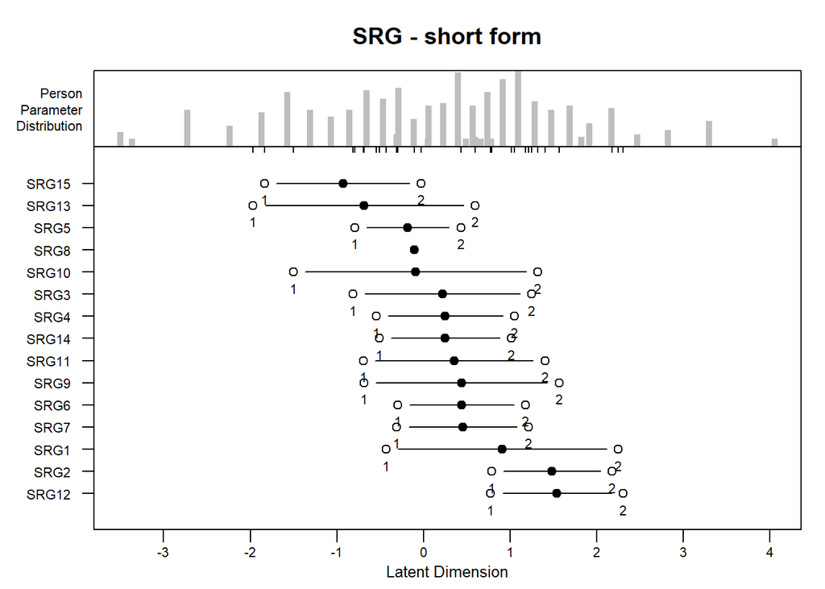

```r
# having done that the PCM analysis and diagnostics are simply re-run on the new
# sample

PCM.srg_rec <- PCM(data.srg)
plotPImap(PCM.srg_rec, sorted = TRUE, main = "SRG - short form")
```

# Exercise

The threshold diagnostics and item collapsing are now illustrated with an exercise on a scale with more issues.

Using the MDS capacity scale (description in the Sampling.html file) investigate step by step the item thresholds with the method(s) of your choice.

What do you notice?

Do the items work as expected?

Try out response collapsing to solve the disordering…

# References

Mair, Patrick. 2018. *Modern Psychometrics with R*.